# WR structure figures

Fátima S. Barreiro

February 16, 2020

In order to thread chunks of code in R and in python, the R package ‘reticulate’ was required.

Load required libraries

```r
library(ggplot2)
library(dplyr)
library(tidyverse)
library(ggpubr)
library(tidyr)
library(cowplot)
library(ggrepel)
```

## PCA with output from PCangsd v 0.973

```r
# prepare metadata
MD <- read.csv("WR_v3_TableS1_v1.csv", h=T)

MD_unrelated = MD[MD$new_ID != 'CD-un.1' & MD$new_ID != 'un1856.1' & MD$new_ID != 'ZA1842.1', ]
```

```r
# prepare covariance matrix
D <-"WR.above13Mb_NoSexChr_NonMaskedRegions_nonRelated_tv.cov"
m <- as.matrix(read.table(D))

# run the eigen decomposition
e <- eigen(m)

# calculate the eigenvalues
eval = e$values/sum(e$values)
```

Select PCs to plot and bind them to metadata

```r
# PC1 and PC2
pcs12 <- e$vectors[,1:2]
evec12 <- cbind(pcs12, MD_unrelated)

# PC2 and PC3
pcs23 <- e$vectors[,2:3]
evec23 <- cbind(pcs23, MD_unrelated)
```

Visualize PCs with legend per subspecies, time window and country of origin

```r
## PC1 vs PC2
A = ggplot(evec12, aes(x=`1`, y=`2`))+

  # draw intercept lines
  geom_vline(xintercept=0, colour="gray", linetype = "longdash")+
  geom_hline(yintercept=0, colour="gray", linetype = "longdash")+

  # plot data points (2 legend alternatives)
  geom_point(aes(colour=time_window, shape=country), alpha=.7, size=2) +

  # assign colors and shapes
  scale_colour_manual(values=c("gold3", "darkorange", "royalblue4", "steelblue3")) +
  scale_shape_manual(values=c(7, 16, 10, 17, 18, 15, 9, 8)) +

  # labels, titles, background, etc.
  xlab(paste0("PC1 (", round(eval[1]*100, 2), "%)"))+
  ylab(paste0("PC2 (", round(eval[2]*100, 2), "%)"))+

  theme(panel.background = element_rect(fill='white', colour='black'), axis.text.x = element_text(colour='black'), axis.text.y = element_text(colour='black'),
        strip.background = element_rect(size=.2, colour="black", fill ="#FFA5004D"), panel.grid.major = element_blank(), panel.grid.minor = element_blank(),
        legend.title=element_text(size=0), legend.key=element_rect(fill="white", colour="white"), axis.title=element_text(size=8), legend.text=element_text(size=7), legend.key.size=unit(.4, "cm"))


## PC2 vs PC3
B = ggplot(evec23, aes(x=`1`, y=`2`))+

  # draw intercept lines
  geom_vline(xintercept=0, colour="gray", linetype = "longdash")+
  geom_hline(yintercept=0, colour="gray", linetype = "longdash")+

  # plot data points with legend per time window and country
  geom_point(aes(colour=time_window, shape=country), alpha=.7, size=2) +

  # assign colors and shapes to time windows and countries
  scale_colour_manual(values=c("gold3", "darkorange", "royalblue4", "steelblue3")) +
  scale_shape_manual(values=c(7, 16, 10, 17, 18, 15, 9, 8)) +

  # labels, titles, background, etc.
  xlab(paste0("PC2 (", round(eval[2]*100, 2), "%)"))+
  ylab(paste0("PC3 (", round(eval[3]*100, 2), "%)"))+

  theme(panel.background = element_rect(fill='white', colour='black'), axis.text.x = element_text(colour='black'), axis.text.y = element_text(colour='black'),
        strip.background = element_rect(size=.2, colour="black", fill ="#FFA5004D"), panel.grid.major = element_blank(), panel.grid.minor = element_blank(),
        legend.title=element_text(size=0), legend.key=element_rect(fill="white", colour="white"), axis.title=element_text(size=8), legend.text=element_text(size=7),
        legend.key.size=unit(.4, "cm"))
```

Extract the legend

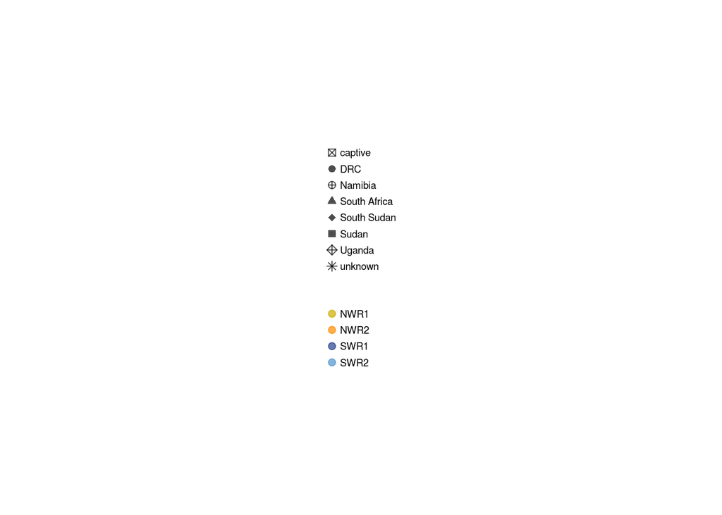

```r
legend = get_legend(B)
as_ggplot(legend)
```

Strip off the legend from both plots

```r
A = A + guides(colour=F, shape=F)
B = B + guides(colour=F, shape=F)
```

Place both PCA plots on same panel

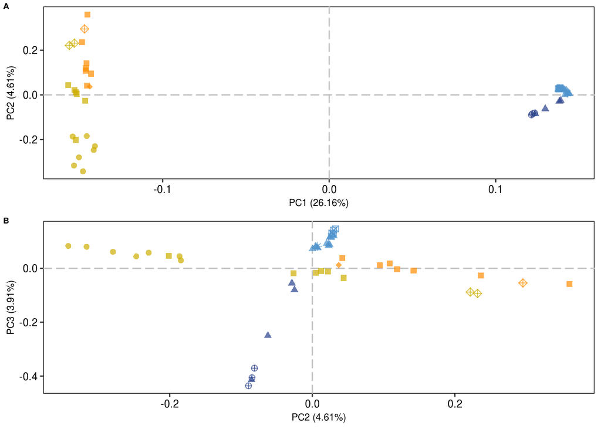

```r
##
PC = plot_grid(A, B, labels=c('A', 'B'), label_size = 7, ncol = 1, nrow = 2)
PC
```

Save figure with the two plots and the legend

```r
pdf('WR_v3_FigS4_v1.pdf', height=5, width=5, useDingbats = F)
plot_grid(PC, legend, nrow=1, ncol=2, rel_widths = c(2,.4))
dev.off()
```

## Reduction of dimensionality with UMAP

#### UMAP from PC data

##### Prep the input for UMAP

```r
## Take the first 30 PCs in the covariance matrix
vectors_30 = e$vectors[,1:30]
values_30 = eval[1:30]

# Find out how much of the total variability is encompassed in these 30 PCs
sum(eval[1:30])
```

```
## [1] 0.832012
```

```r
# Multiply each eigenvector by its corresponding eigenvalue
pcs_30 = sweep(vectors_30, 2, values_30, "*")

# Assign corresponding column names to the new dataframe
colnames(pcs_30) = c("PC1", "PC2", "PC3", "PC4", "PC5", "PC6", "PC7", "PC8", "PC9", "PC10",
                     "PC11", "PC12", "PC13", "PC14", "PC15", "PC16", "PC17", "PC18", "PC19", "PC20", "PC21",
                     "PC22", "PC23", "PC24", "PC25", "PC26", "PC27", "PC28", "PC29", "PC30")
```

```r
# write out as a table
write.table(pcs_30, "WR_NonRelated_30pcs.txt", sep="\t")
```

### Computing embeddings of PC data with UMAP

Install required modules

```bash
pip3 install numpy
pip3 install pandas
pip3 install umap
```

Load the required modules

```python
# import required packages and libraries
import numpy as np
import pandas as pd
import umap
```

Load the dataframe from PC data parsing above

```python
# import data and turn it into array
PCs = pd.read_csv("WR_NonRelated_30pcs.txt", sep='\t')
PCs.to_numpy()
```

```
## array([[ 3.63650367e-02, -1.15144126e-03, -3.14137514e-03, ...,
##          8.21716217e-03, -2.37495202e-03,  2.55684093e-03],
##        [-3.69857439e-02, -1.13756548e-02,  1.73928707e-03, ...,
##          9.44321202e-05, -3.06345277e-04,  1.23885773e-04],
##        [-3.80799443e-02, -8.49378752e-03,  1.14802707e-03, ...,
##          1.67569100e-04, -4.50553967e-04,  1.97020666e-04],
##        ...,
##        [-3.84330342e-02,  1.36168062e-02, -2.12601821e-03, ...,
##         -1.02648143e-05,  3.95595919e-06,  7.69547308e-05],
##        [-3.81013846e-02,  6.55513906e-03, -3.08047117e-04, ...,
##         -8.54402562e-05, -3.17076177e-05,  5.62608266e-05],
##        [ 3.69381684e-02,  1.05289484e-03,  3.52281959e-03, ...,
##         -3.39928302e-04,  1.47106816e-03,  3.30944562e-03]])
```

Call the reducer function from UMAP

```python
reducer = umap.UMAP()
```

Reduce dimensionality with UMAP

```python
# train the model in umap with your data and reduce dimensionality of your dataset
embedding = reducer.fit_transform(PCs)

# the shape of the output should be n_samples x 2
embedding.shape
```

```
## (49, 2)
```

Save the output for visualization

```python
# save output of umap as a text file to plot elsewhere
np.savetxt('WR_NonRelated_30pcs_embedding.txt', embedding, '%6.2f')
```

### UMAP output from GLs instead of from PC data (20.4.2020)

The embeddings were calculated in Computerome, the output is visualized here.

Retrieve the output from UMAP

```r
# get embedding from umap
embeddings = read.table ("WR.above13Mb_NoSexChr_NonMaskedRegions_nonRelated_tv.emb.txt", h=F)
colnames(embeddings) = c('E1', 'E2')

emb = cbind(embeddings, MD_unrelated)
```

Visualize the 2-dimensional embeddings

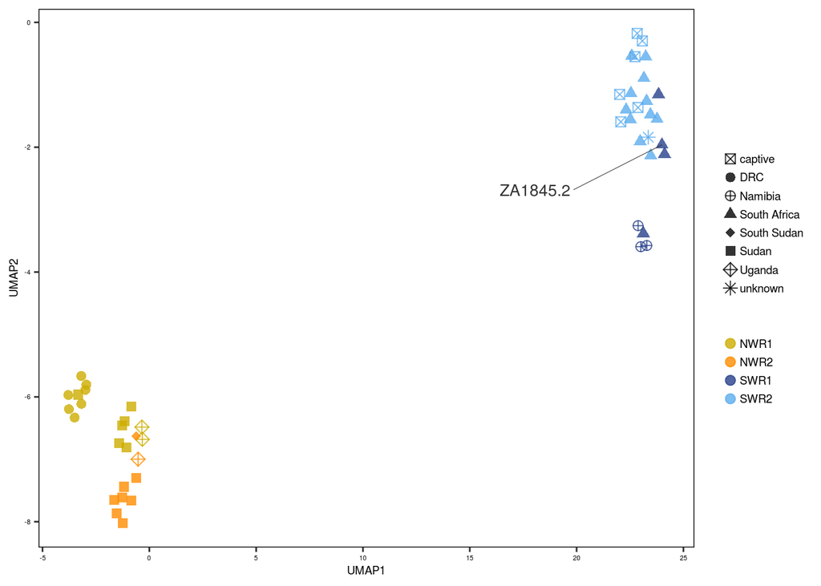

```r
Ep = ggplot(emb, aes(E1, E2)) +
  geom_point(aes(colour=time_window, shape=country), alpha=.8, size=2.5) +

  # assign colors and shapes
  scale_colour_manual(values=c("gold3", "darkorange", "royalblue4", "steelblue2")) +
  scale_shape_manual(values=c(7, 16, 10, 17, 18, 15, 9, 8))

Ep = Ep +  xlab('UMAP1') + ylab('UMAP2') +
  theme(panel.background = element_rect(fill='white', colour='black'), axis.text.x = element_text(colour='black'),
        axis.text.y = element_text(colour='black'),
        strip.background = element_rect(size=.2, colour="black", fill ="#FFA5004D"), panel.grid.major = element_blank(),
        panel.grid.minor = element_blank(),
        legend.title=element_text(size=0), legend.key=element_rect(fill="white", colour="white"),
        legend.key.size=unit(.4, 'cm'), legend.text=element_text(size=7),
        axis.title=element_text(size=7), axis.text=element_text(size=4))

Ep = Ep + geom_text_repel(data=subset(emb, new_ID == "ZA1845.2"), aes(label=new_ID), segment.size=.18, size=3.5, colour="gray20", ylim=c(NA, -2.5), xlim=c(NA, 20))

Ep
```

```r
pdf('WR_v3_Fig2A_v2.pdf', height=4, width=8, useDingbats = F)
Ep
dev.off()
```

## Admixture analysis with output from ngsAdmix v 32 plot with pong

```bash
#pong -m nonRelatedFilemap -i nonRelated_ind2pop_samples.txt -n nonRelated_poporder_final_newids.txt -l colourpalette_k6.txt
```